# 6월 27일 과제

황 성 윤

2019 6 27

## 1. mtcars 데이터셋에서 자동차 기어 종류(am: 오토/수동)에 따른 mpg의 차이가 통계적으로 유의한지 t-test를 통해 확인해 보시오.

```r
mtcars <- mtcars
```

집단1 –> am==1 (수동) , 집단2 –> am==0 (자동)  
기어의 종류가 다른 자동차는 서로 독립이라고 가정한다.  
먼저, 기어 종류에 따른 mpg가 정규성을 나타내는 지 검정한다.

```r
mtcars$mpg[mtcars$am==1]
```

```
##  [1] 21.0 21.0 22.8 32.4 30.4 33.9 27.3 26.0 30.4 15.8 19.7 15.0 21.4
```

```r
shapiro.test(mtcars$mpg[mtcars$am==1])
```

```
##
##  Shapiro-Wilk normality test
##
## data:  mtcars$mpg[mtcars$am == 1]
## W = 0.9458, p-value = 0.5363
```

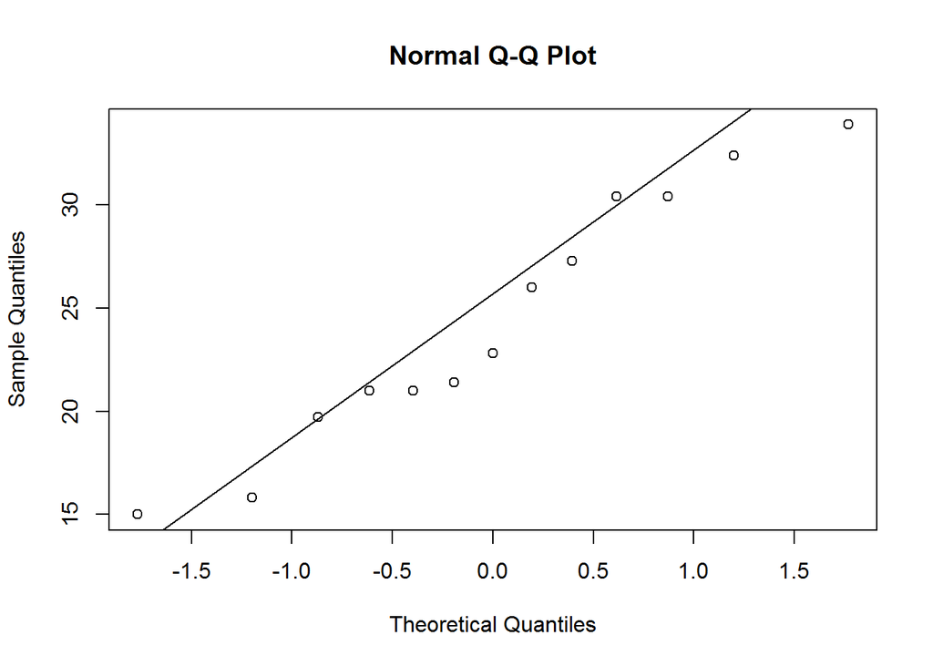

```r
qqnorm(mtcars$mpg[mtcars$am==1]) ; qqline(mtcars$mpg[mtcars$am==1])
```

```r
mtcars$mpg[mtcars$am==0]
```

```
##  [1] 21.4 18.7 18.1 14.3 24.4 22.8 19.2 17.8 16.4 17.3 15.2 10.4 10.4 14.7
## [15] 21.5 15.5 15.2 13.3 19.2
```

```r
shapiro.test(mtcars$mpg[mtcars$am==0])
```

```
##
##  Shapiro-Wilk normality test
##
## data:  mtcars$mpg[mtcars$am == 0]
## W = 0.97677, p-value = 0.8987
```

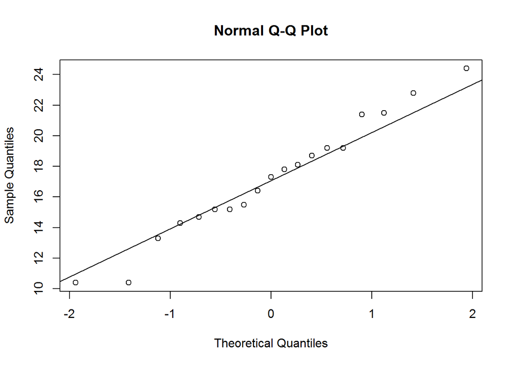

```r
qqnorm(mtcars$mpg[mtcars$am==0]) ; qqline(mtcars$mpg[mtcars$am==0])
```

검정결과 두가지 경우 모두 p-value가 0.5 이상으로 상당히 크게 나왔다.  
그러므로 유의수준 0.05 하에서 기어의 종류에 상관없이 mpg는 정규분포를 따른다고 결론내린다.  
이제 두 집단의 분산이 같은지 검정해본다.  
Hypothesis  
H0 : sigma1==sigma2 v.s H1 : sigma1!=sigma2

```r
var.test(mtcars$mpg~mtcars$am)
```

```
##
##  F test to compare two variances
##
## data:  mtcars$mpg by mtcars$am
## F = 0.38656, num df = 18, denom df = 12, p-value = 0.06691
## alternative hypothesis: true ratio of variances is not equal to 1
## 95 percent confidence interval:
##  0.1243721 1.0703429
## sample estimates:
## ratio of variances
##          0.3865615
```

검정결과 p-value의 값이 약 0.067 로 나왔으며, 이에 따라 유의수준 0.05 하에서 두 집단의 분산은 같은 것으로 결론내린다.  
이에 따라 분산이 같다는 가정 하에서 모평균의 차이를 검정한다.  
Hypothesis  
H0 : mu1==mu2 v.s H1 : mu1!=mu2

```r
t.test(mtcars$mpg~mtcars$am,var.equal=T)
```

```
##
##  Two Sample t-test
##
## data:  mtcars$mpg by mtcars$am
## t = -4.1061, df = 30, p-value = 0.000285
## alternative hypothesis: true difference in means is not equal to 0
## 95 percent confidence interval:
##  -10.84837  -3.64151
## sample estimates:
## mean in group 0 mean in group 1
##        17.14737        24.39231
```

검정결과 p-value가 약 0.0003으로 매우 작은 값이다. 따라서 유의수준 0.05 하에서 귀무가설을 기각한다. 이에 따라 자동차의 기어 종류에 따라 mpg는 차이가 있다고 결론내린다.

## 2. MASS 패키지에 내장된 Cars93 데이터프레임에 대해서 생산국(Origin)이 USA vs. non-USA 2개의 group 에 대해서 차 가격(Price)의 평균이 차이가 있는지를 검정해보시오.

```r
library(MASS)
Cars93 <- Cars93
```

집단1 –> non-USA , 집단2 –> USA  
위의 두 집단은 서로 독립이라고 가정한다.  
먼저, 생산국에 따른 가격이 정규성을 나타내는 지 검정한다.

```r
Cars93$Price[Cars93$Origin=="non-USA"]
```

```
##  [1] 15.9 33.9 29.1 37.7 30.0  8.4 12.5 19.8 12.1 17.5  8.0 10.0 10.0 13.9
## [15] 47.9 28.0 35.2  8.3 11.6 16.5 19.1 32.5 31.9 61.9 10.3 26.1 11.8 15.7
## [29] 19.1 21.5 28.7  8.4 10.9 19.5  8.6  9.8 18.4 18.2 22.7  9.1 19.7 20.0
## [43] 23.3 22.7 26.7
```

```r
shapiro.test(Cars93$Price[Cars93$Origin=="non-USA"])
```

```
##
##  Shapiro-Wilk normality test
##
## data:  Cars93$Price[Cars93$Origin == "non-USA"]
## W = 0.87756, p-value = 0.0002036
```

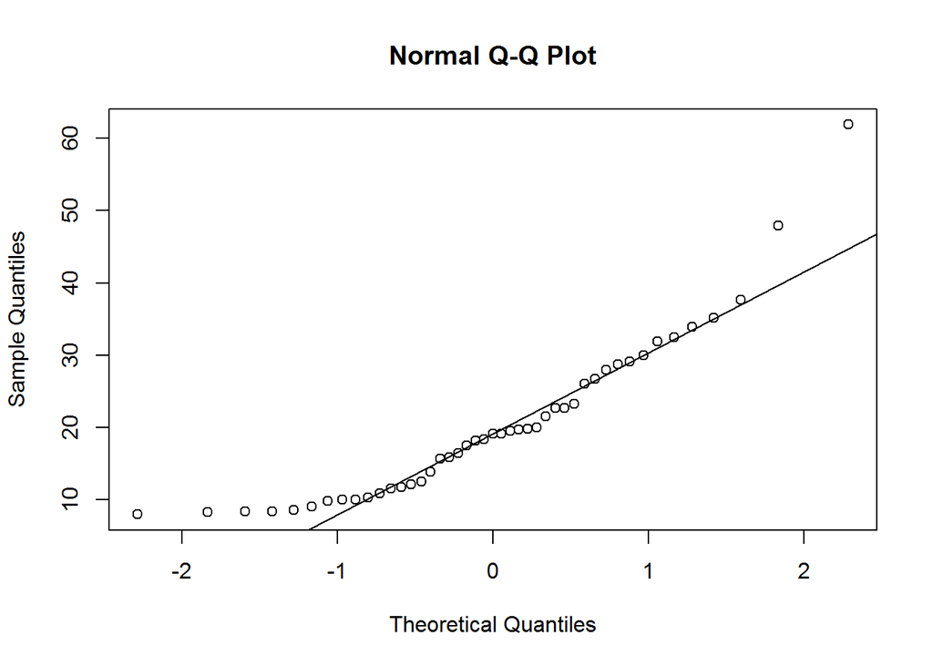

```r
qqnorm(Cars93$Price[Cars93$Origin=="non-USA"]) ; qqline(Cars93$Price[Cars93$Origin=="non-USA"])
```

```r
Cars93$Price[Cars93$Origin=="USA"]
```

```
##  [1] 15.7 20.8 23.7 26.3 34.7 40.1 13.4 11.4 15.1 15.9 16.3 16.6 18.8 38.0
## [15] 18.4 15.8 29.5  9.2 11.3 13.3 19.0 15.6 25.8 12.2 19.3  7.4 10.1 11.3
## [29] 15.9 14.0 19.9 20.2 20.9 34.3 36.1 14.1 14.9 13.5 16.3 19.5 20.7 14.4
## [43]  9.0 11.1 17.7 18.5 24.4 11.1
```

```r
shapiro.test(Cars93$Price[Cars93$Origin=="USA"])
```

```
##
##  Shapiro-Wilk normality test
##
## data:  Cars93$Price[Cars93$Origin == "USA"]
## W = 0.88411, p-value = 0.0002006
```

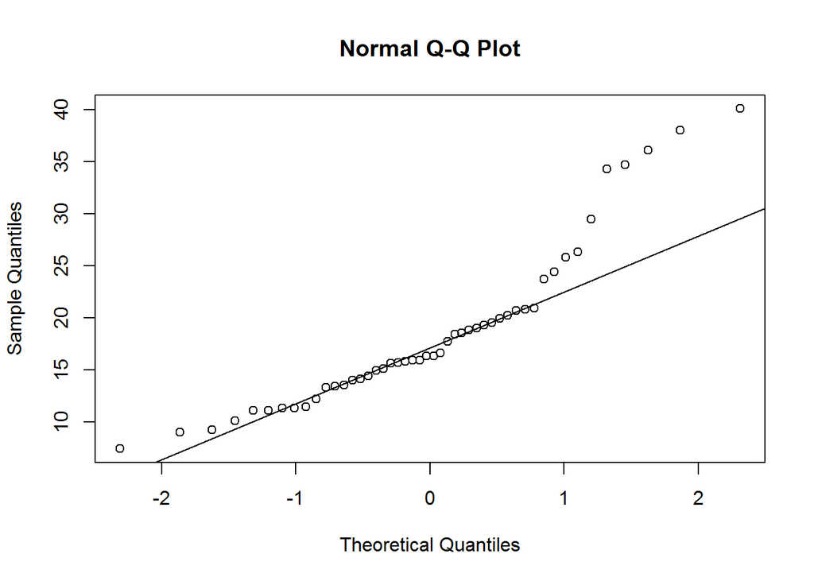

```r
qqnorm(Cars93$Price[Cars93$Origin=="USA"]) ; qqline(Cars93$Price[Cars93$Origin=="USA"])
```

검정결과 두 집단 모두 p-value의 값이 굉장히 작게 나왔으므로, 유의수준 0.05 하에서 두 집단의 가격은 정규분포를 따르지 않는다고 결론내린다. 이에 따라 다음과 같이 두가지의 경우로 나누어서 검정해보겠다.

### 비모수적 통계검정 사용 (Wilcoxon rank sum test)

–> 해당하는 관측치를 소속집단에 상관없이 크기순으로 나열 후 순위를 합한 다음 통계량을 계산하여 검정하는 대표적인 2-sample non-parameter test  
Hypothesis  
H0 : mu1==mu2 v.s H1 : mu1!=mu2

```r
wilcox.test(Cars93$Price~Cars93$Origin)
```

```
##
##  Wilcoxon rank sum test with continuity correction
##
## data:  Cars93$Price by Cars93$Origin
## W = 1024.5, p-value = 0.6724
## alternative hypothesis: true location shift is not equal to 0
```

검정결과, p-value의 값이 0.6724로 매우 큰 값이다. 따라서 유의수준 0.05 하에서 귀무가설을 기각하지 못하게 되고, 생산국에 따른 가격의 평균은 차이가 없다고 결론내린다.

### 모수적 통계검정 사용 (2-sample T-test)

만약 두 집단의 가격이 모두 정규분포를 따른다고 가정한다면 2-sample T-test를 사용한다. 먼저 두 집단의 등분산성을 검정한다.  
Hypothesis  
H0 : sigma1==sigma2 v.s H1 : sigma1!=sigma2

```r
var.test(Cars93$Price~Cars93$Origin)
```

```
##
##  F test to compare two variances
##
## data:  Cars93$Price by Cars93$Origin
## F = 0.47796, num df = 47, denom df = 44, p-value = 0.01387
## alternative hypothesis: true ratio of variances is not equal to 1
## 95 percent confidence interval:
##  0.2645004 0.8587304
## sample estimates:
## ratio of variances
##          0.4779637
```

검정결과, p-value의 값이 약 0.014이므로, 유의수준 0.05 하에서 두 집단의 분산은 다르다고 결론내린다. 이에 따라 이분산을 가정한 T검정을 수행한다. 이 검정은 모집단의 분산을 표본의 분산으로 가정하여 근사시킨 자유도를 이용한다.  
Hypothesis  
H0 : mu1==mu2 v.s H1 : mu1!=mu2

```r
t.test(Cars93$Price~Cars93$Origin,var.equal=F)
```

```
##
##  Welch Two Sample t-test
##
## data:  Cars93$Price by Cars93$Origin
## t = -0.95449, df = 77.667, p-value = 0.3428
## alternative hypothesis: true difference in means is not equal to 0
## 95 percent confidence interval:
##  -5.974255  2.102311
## sample estimates:
##     mean in group USA mean in group non-USA
##              18.57292              20.50889
```

검정결과, p-value의 값이 0.3428로 유의수준 0.05보다 큰 값이다. 따라서 귀무가설을 기각하지 못하고, 이에 따라 생산국에 따른 가격의 평균은 차이가 없다고 결론내린다.

## 3. mpg 데이터셋에서 다음을 검정해 보시오.

## 3-1. subcompact 자동차와 midsize 자동차의 고속도로 연비

```r
library(ggplot2)
mpg <- mpg
```

집단1 –> class==“subcompact” , 집단2 –> class==“midsize”  
위의 두 집단은 서로 독립이라고 가정한다.  
먼저, 두 집단에 따른 고속도로 연비(hwy)가 정규성을 나타내는 지 검정한다.

```r
mpg$hwy[mpg$class=="subcompact"]
```

```
##  [1] 26 25 26 24 21 22 23 22 20 33 32 32 29 32 34 36 36 29 26 29 28 27 24
## [24] 24 24 26 26 26 26 44 41 29 26 28 29
```

```r
shapiro.test(mpg$hwy[mpg$class=="subcompact"])
```

```
##
##  Shapiro-Wilk normality test
##
## data:  mpg$hwy[mpg$class == "subcompact"]
## W = 0.91514, p-value = 0.01036
```

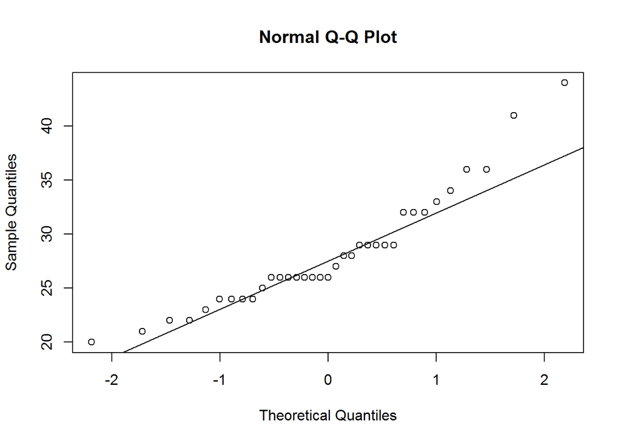

```r
qqnorm(mpg$hwy[mpg$class=="subcompact"]) ; qqline(mpg$hwy[mpg$class=="subcompact"])
```

```r
mpg$hwy[mpg$class=="midsize"]
```

```
##  [1] 24 25 23 27 30 26 29 26 26 27 30 31 26 26 28 31 32 27 26 26 25 25 26
## [24] 26 27 28 25 29 27 31 31 26 26 28 29 29 28 29 26 26 26
```

```r
shapiro.test(mpg$hwy[mpg$class=="midsize"])
```

```
##
##  Shapiro-Wilk normality test
##
## data:  mpg$hwy[mpg$class == "midsize"]
## W = 0.92873, p-value = 0.01311
```

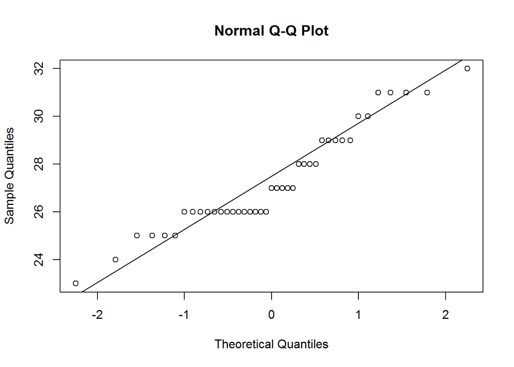

```r
qqnorm(mpg$hwy[mpg$class=="midsize"]) ; qqline(mpg$hwy[mpg$class=="midsize"])
```

검정결과, 두 집단 모두 p-value의 값이 유의수준 0.05보다 작다. 따라서 두 집단 모두 정규분포를 따르지 않는다고 결론내린다. 이에 따라 다음과 같이 두가지의 경우로 나누어서 검정한다.

### 비모수적 통계검정 사용 (Wilcoxon rank sum test)

Hypothesis  
H0 : mu1==mu2 v.s H1 : mu1!=mu2

```r
library(dplyr)
mpg1 <- mpg %>%
  filter(class %in% c("subcompact","midsize"))
wilcox.test(mpg1$hwy~mpg1$class)
```

```
##
##  Wilcoxon rank sum test with continuity correction
##
## data:  mpg1$hwy by mpg1$class
## W = 719, p-value = 0.9916
## alternative hypothesis: true location shift is not equal to 0
```

검정결과, p-value의 값이 0.9916로 매우 큰 값이다. 따라서 유의수준 0.05 하에서 귀무가설을 기각하지 못하게 되고, subcompact 자동차와 midsize 자동차의 고속도로 연비는 차이가 없다고 결론내린다.

### 모수적 통계검정 사용 (2-sample T-test)

만약 두 집단의 가격이 모두 정규분포를 따른다고 가정한다면 2-sample T-test를 사용한다. 먼저 두 집단의 등분산성을 검정한다.  
Hypothesis  
H0 : sigma1==sigma2 v.s H1 : sigma1!=sigma2

```r
var.test(mpg1$hwy~mpg1$class)
```

```
##
##  F test to compare two variances
##
## data:  mpg1$hwy by mpg1$class
## F = 0.15791, num df = 40, denom df = 34, p-value = 8.825e-08
## alternative hypothesis: true ratio of variances is not equal to 1
## 95 percent confidence interval:
##  0.08116414 0.30185921
## sample estimates:
## ratio of variances
##          0.1579119
```

검정결과, p-value의 값이 굉장히 작으므로, 유의수준 0.05 하에서 두 집단의 분산은 다르다고 결론내린다. 이에 따라 이분산을 가정한 T검정을 수행한다.  
Hypothesis  
H0 : mu1==mu2 v.s H1 : mu1!=mu2

```r
t.test(mpg1$hwy~mpg1$class,var.equal=F)
```

```
##
##  Welch Two Sample t-test
##
## data:  mpg1$hwy by mpg1$class
## t = -0.87842, df = 43.118, p-value = 0.3846
## alternative hypothesis: true difference in means is not equal to 0
## 95 percent confidence interval:
##  -2.801864  1.101515
## sample estimates:
##    mean in group midsize mean in group subcompact
##                 27.29268                 28.14286
```

검정결과, p-value의 값이 0.3846로 유의수준 0.05보다 큰 값이다. 따라서 귀무가설을 기각하지 못하고, 이에 따라 subcompact 자동차와 midsize 자동차의 고속도로 연비는 차이가 없다고 결론내린다.

### 3-2. 일반 휘발유(r)와 고급 휘발유(p)의 도시 연비

집단1 –> fl==“r” , 집단2 –> fl==“p”  
위의 두 집단은 서로 독립이라고 가정한다.  
먼저, 두 집단에 따른 도시 연비(cty)가 정규성을 나타내는 지 검정한다.

```r
mpg$cty[mpg$fl=="r"]
```

```
##   [1] 14 14 13 12 14 11 19 22 18 18 17 18 17 16 16 17 17 15 15 16 16 15 14
##  [24] 13 14 14 14 11 11 13 13 13 11 13 11 12 13 13 12 11 11 13 11 11 11 12
##  [47] 14 15 14 13 13 13 14 14 13 13 13 11 13 18 18 17 16 15 15 15 15 28 24
##  [70] 25 24 26 25 18 18 21 21 18 18 19 19 19 20 20 17 16 17 15 15 14 14 13
##  [93] 12 12 11 12 14 13 13 13 21 19 23 23 18 19 14 15 18 17 18 18 18 20 20
## [116] 21 19 19 19 20 20 15 16 15 15 16 14 21 21 21 21 18 18 19 21 21 21 22
## [139] 18 18 18 24 24 26 28 26 11 13 15 16 17 15 15 15 16 21 19 17 21 19 21
## [162] 21 16 17 21 19 20 20
```

```r
shapiro.test(mpg$cty[mpg$fl=="r"])
```

```
##
##  Shapiro-Wilk normality test
##
## data:  mpg$cty[mpg$fl == "r"]
## W = 0.9542, p-value = 2.7e-05
```

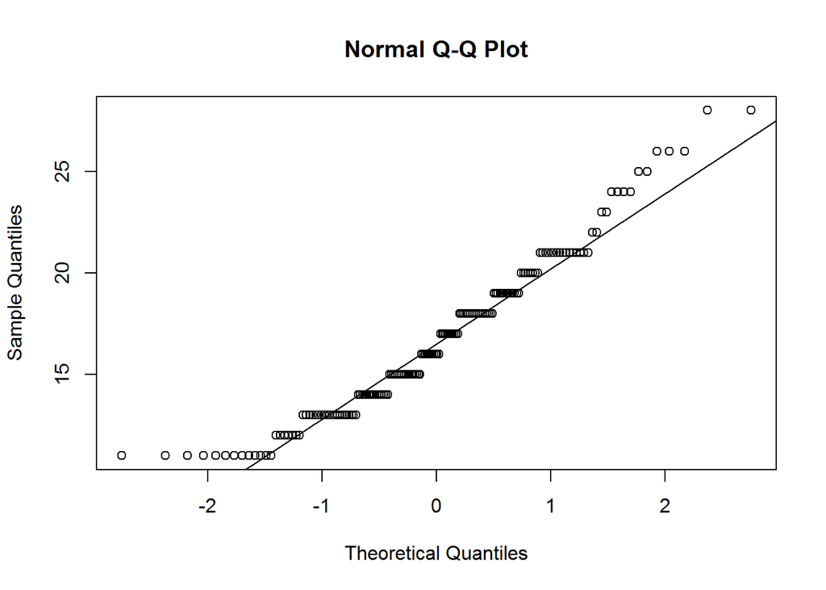

```r
qqnorm(mpg$cty[mpg$fl=="r"]) ; qqline(mpg$cty[mpg$fl=="r"])
```

```r
mpg$cty[mpg$fl=="p"]
```

```
##  [1] 18 21 20 21 16 18 18 18 16 20 19 15 17 17 15 15 17 16 16 15 16 15 15
## [24] 14 23 21 11 11 11 11 19 19 19 14 12 16 16 19 18 20 19 21 22 22 21 21
## [47] 18 19 21 16 18 17
```

```r
shapiro.test(mpg$cty[mpg$fl=="p"])
```

```
##
##  Shapiro-Wilk normality test
##
## data:  mpg$cty[mpg$fl == "p"]
## W = 0.95546, p-value = 0.04984
```

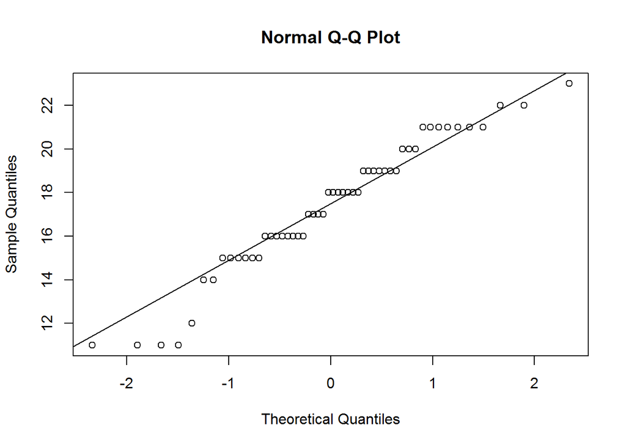

```r
qqnorm(mpg$cty[mpg$fl=="p"]) ; qqline(mpg$cty[mpg$fl=="p"])
```

검정결과, 두 집단 모두 p-value의 값이 유의수준 0.05보다 작다. 따라서 두 집단 모두 정규분포를 따르지 않는다고 결론내린다. 이에 따라 다음과 같이 두가지의 경우로 나누어서 검정한다.

### 비모수적 통계검정 사용 (Wilcoxon rank sum test)

Hypothesis  
H0 : mu1==mu2 v.s H1 : mu1!=mu2

```r
mpg2 <- mpg %>%
  filter(fl %in% c("r","p"))
wilcox.test(mpg2$cty~mpg2$fl)
```

```
##
##  Wilcoxon rank sum test with continuity correction
##
## data:  mpg2$cty by mpg2$fl
## W = 5027.5, p-value = 0.09906
## alternative hypothesis: true location shift is not equal to 0
```

검정결과, p-value의 값이 약 0.099 유의수준 0.05보다 큰 값이다. 따라서 귀무가설을 기각하지 못하게 되고, 일반 휘발유와 고급 휘발유의 도시 연비는 차이가 없다고 결론내린다.

### 모수적 통계검정 사용 (2-sample T-test)

만약 두 집단의 가격이 모두 정규분포를 따른다고 가정한다면 2-sample T-test를 사용한다. 먼저 두 집단의 등분산성을 검정한다.  
Hypothesis  
H0 : sigma1==sigma2 v.s H1 : sigma1!=sigma2

```r
var.test(mpg2$cty~mpg2$fl)
```

```
##
##  F test to compare two variances
##
## data:  mpg2$cty by mpg2$fl
## F = 0.61231, num df = 51, denom df = 167, p-value = 0.04282
## alternative hypothesis: true ratio of variances is not equal to 1
## 95 percent confidence interval:
##  0.402103 0.983840
## sample estimates:
## ratio of variances
##          0.6123082
```

검정결과, p-value의 값이 약 0.043이므로, 유의수준 0.05 하에서 두 집단의 분산은 다르다고 결론내린다. 이에 따라 이분산을 가정한 T검정을 수행한다.  
Hypothesis  
H0 : mu1==mu2 v.s H1 : mu1!=mu2

```r
t.test(mpg2$cty~mpg2$fl,var.equal=F)
```

```
##
##  Welch Two Sample t-test
##
## data:  mpg2$cty by mpg2$fl
## t = 1.2118, df = 107.23, p-value = 0.2283
## alternative hypothesis: true difference in means is not equal to 0
## 95 percent confidence interval:
##  -0.3989031  1.6534818
## sample estimates:
## mean in group p mean in group r
##        17.36538        16.73810
```

검정결과, p-value의 값이 0.2283로 유의수준 0.05보다 큰 값이다. 따라서 귀무가설을 기각하지 못하고, 이에 따라 일반 휘발유와 고급 휘발유의 도시 연비는 차이가 없다고 결론내린다.

### 3-3. subcompact 자동차의 전륜구동(f)이냐 후륜구동(r)이냐에 따른 도시 연비

```r
mpg3 <- mpg %>%
  filter(class=="subcompact" & drv %in% c("f","r"))
```

집단1 –> drv==“f” , 집단2 –> drv==“r”  
위의 두 집단은 서로 독립이라고 가정한다.  
먼저, 두 집단에 따른 도시 연비(cty)가 정규성을 나타내는 지 검정한다.

```r
mpg3$cty[mpg3$drv=="f"]
```

```
##  [1] 28 24 25 23 24 26 25 24 21 19 19 20 20 17 16 17 35 29 21 19 20 20
```

```r
shapiro.test(mpg3$cty[mpg3$drv=="f"])
```

```
##
##  Shapiro-Wilk normality test
##
## data:  mpg3$cty[mpg3$drv == "f"]
## W = 0.92488, p-value = 0.09599
```

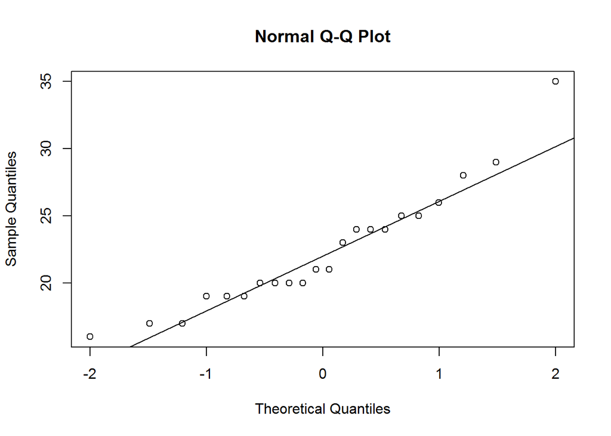

```r
qqnorm(mpg3$cty[mpg3$drv=="f"]) ; qqline(mpg3$cty[mpg3$drv=="f"])
```

```r
mpg3$cty[mpg3$drv=="r"]
```

```
## [1] 18 18 17 16 15 15 15 15 14
```

```r
shapiro.test(mpg3$cty[mpg3$drv=="r"])
```

```
##
##  Shapiro-Wilk normality test
##
## data:  mpg3$cty[mpg3$drv == "r"]
## W = 0.86355, p-value = 0.1048
```

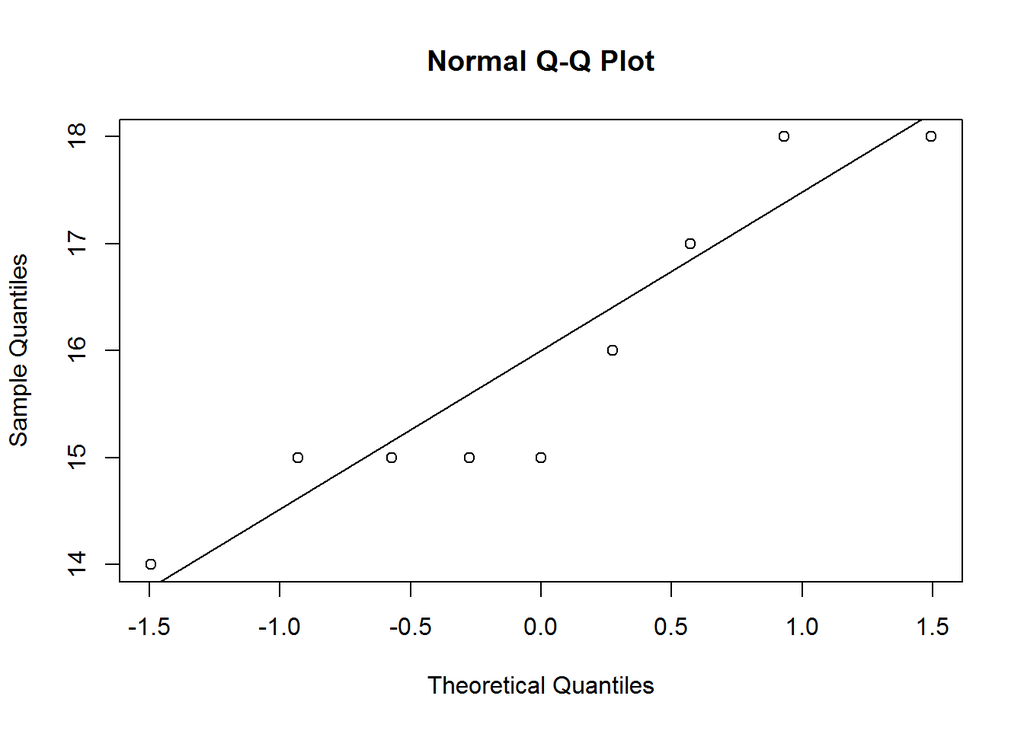

```r
qqnorm(mpg3$cty[mpg3$drv=="r"]) ; qqline(mpg3$cty[mpg3$drv=="r"])
```

검정결과, 두 집단 모두 p-value의 값이 유의수준 0.05보다 크다. 따라서 두 집단 모두 정규분포를 따른다고 결론내린다.  
이제 두 집단의 분산이 같은지 검정한다.  
Hypothesis  
H0 : sigma1==sigma2 v.s H1 : sigma1!=sigma2

```r
var.test(mpg3$cty~mpg3$drv)
```

```
##
##  F test to compare two variances
##
## data:  mpg3$cty by mpg3$drv
## F = 9.6787, num df = 21, denom df = 8, p-value = 0.002612
## alternative hypothesis: true ratio of variances is not equal to 1
## 95 percent confidence interval:
##   2.429022 27.816698
## sample estimates:
## ratio of variances
##           9.678742
```

검정결과, p-value의 값이 약 0.003이므로, 유의수준 0.05 하에서 두 집단의 분산은 다르다고 결론내린다. 이에 따라 이분산을 가정한 T검정을 수행한다.  
Hypothesis  
H0 : mu1==mu2 v.s H1 : mu1!=mu2

```r
t.test(mpg3$cty~mpg3$drv,var.equal=F)
```

```
##
##  Welch Two Sample t-test
##
## data:  mpg3$cty by mpg3$drv
## t = 6.003, df = 28.222, p-value = 1.759e-06
## alternative hypothesis: true difference in means is not equal to 0
## 95 percent confidence interval:
##  4.266157 8.683338
## sample estimates:
## mean in group f mean in group r
##        22.36364        15.88889
```

검정결과, p-value의 값이 유의수준 0.05보다 매우 작게 나온다. 따라서 귀무가설을 기각하게 되고, 이에 따라 subcompact 자동차의 전륜구동이냐 후륜구동이냐에 따른 도시 연비는 차이가 있다고 결론내린다.

## 4. 새로운 당뇨병 치료제를 개발한 제약사에서는 치료에 지대한 영향을 주는 외부요인을 통제하기 위해 10명의 당뇨병 환자를 선별하여 1달 동안 ’위약(placebo)’을 투여한 기간의의 혈당 수치(Xi)와 ’신약(new medicine)’을 투여한 1달 기간 동안의 혈당 수치(Yi)를 측정하여 짝을 이루어 혈당 차이를 유의수준 5%에서 비교하시오.

```r
placebo <- c(51.4,52.0,45.5,54.5,52.3,50.9,52.7,50.3,53.8,53.1)
newmd <- c(50.1,51.5,45.9,53.1,51.8,50.3,52.0,49.9,52.5,53.0)
diabetes <- data.frame(placebo=placebo,newmd=newmd)
```

먼저 혈당 수치의 차이가 정규성을 나타내는 지 검정한다.

```r
shapiro.test(diabetes$placebo-diabetes$newmd)
```

```
##
##  Shapiro-Wilk normality test
##
## data:  diabetes$placebo - diabetes$newmd
## W = 0.92988, p-value = 0.4467
```

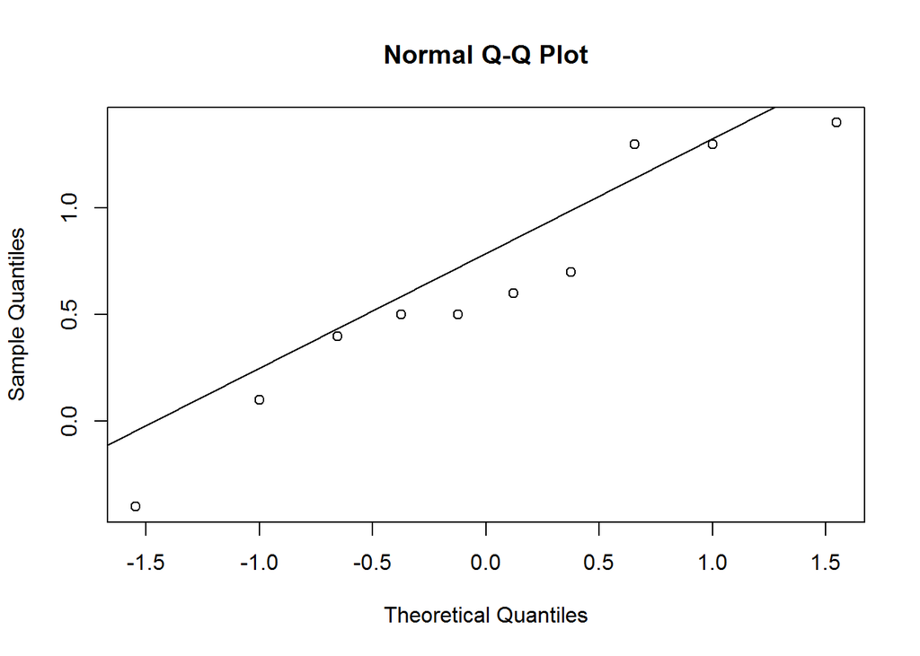

```r
qqnorm(diabetes$placebo-diabetes$newmd) ; qqline(diabetes$placebo-diabetes$newmd)
```

검정결과, p-value의 값이 0.4467로 유의수준 0.05보다 크다. 따라서 혈당 수치의 차이는 정규분포를 따른다고 결론내리고, 이에 따라 paired sample T-test를 실시한다.  
Hypothesis  
H0 : muD==0 v.s H1 : muD!=0

```r
t.test(diabetes$placebo,diabetes$newmd,paired=T)
```

```
##
##  Paired t-test
##
## data:  diabetes$placebo and diabetes$newmd
## t = 3.5507, df = 9, p-value = 0.006209
## alternative hypothesis: true difference in means is not equal to 0
## 95 percent confidence interval:
##  0.2322535 1.0477465
## sample estimates:
## mean of the differences
##                    0.64
```

검정결과, p-value의 값이 약 0.006으로 유의수준 0.05보다 작게 나온다. 따라서 귀무가설을 기각하게 되고, 이에 따라 투여한 약에 따라 혈당 차이가 존재한다고 결론내린다.

## 5. 두 종류의 신발 밑창의 원재료가 닳는 정도가 차이가 있는지를 검정하기 위해서 10명의 소년에게 한쪽은 A라는 원재료로 만든 신발을 신기고, 다른 한쪽은 B라는 원재료로 만든 신발을 신긴 후에, 일정 기간이 지난후에 신발을 수거하여 10명의 각 소년의 왼쪽 신발 밑창의 닳은 정도와 오른쪽 신발 밑창의 닳은 정도의 차이를 비교하여 두 종류 원재료의 재질이 다른지를 검정하시오.

```r
A <- c(13.2,8.2,10.9,14.3,10.7,6.6,9.5,10.8,8.8,13.3)
B <- c(14.0,8.8,11.2,14.2,11.8,6.4,9.8,11.3,9.3,13.6)
shoes <- data.frame(A=A,B=B)
```

먼저 신발 밑창의 닳은 정도의 차이가 정규성을 나타내는 지 검정한다.

```r
shapiro.test(shoes$A-shoes$B)
```

```
##
##  Shapiro-Wilk normality test
##
## data:  shoes$A - shoes$B
## W = 0.96132, p-value = 0.8009
```

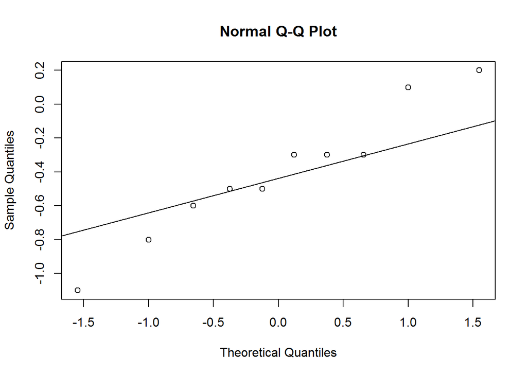

```r
qqnorm(shoes$A-shoes$B) ; qqline(shoes$A-shoes$B)
```

검정결과, p-value의 값이 0.8009로 유의수준 0.05보다 크다. 따라서 신발 밑창의 닳은 정도의 차이는 정규분포를 따른다고 결론내리고, 이에 따라 paired sample T-test를 실시한다.  
Hypothesis  
H0 : muD==0 v.s H1 : muD!=0

```r
t.test(shoes$A,shoes$B,paired=T)
```

```
##
##  Paired t-test
##
## data:  shoes$A and shoes$B
## t = -3.3489, df = 9, p-value = 0.008539
## alternative hypothesis: true difference in means is not equal to 0
## 95 percent confidence interval:
##  -0.6869539 -0.1330461
## sample estimates:
## mean of the differences
##                   -0.41
```

검정결과, p-value의 값이 약 0.009로 유의수준 0.05보다 작다. 따라서 귀무가설을 기각하게 되고, 이에 따라 재질에 따라 신발 밑창의 닳은 정도는 차이가 있다고 결론내린다.

## 6. 다음은 3개 호수의 산소량의 차이가 있는지 없는지 알아보기 위하여 각 호수에서 10곳을 선택하여 수심 1m의 물로부터 산소량(ppm)을 측정한 자료이다.3개 호수의 산소량이 같다고 할 수 있는가?

```r
group <- c(rep("1",10),rep("2",10),rep("3",10))
lake1 <- c(5,7,6,8,6,7,8,8,6,10)
lake2 <- c(6,8,9,11,13,12,10,8,9,10)
lake3 <- c(14,25,26,18,19,22,21,16,20,30)
ppm <- c(lake1,lake2,lake3)
lake <- data.frame(group=group,ppm=ppm)
```

우선 각 호수 별 산소량이 정규성을 나타내는 지 검정한다.

```r
shapiro.test(lake1)
```

```
##
##  Shapiro-Wilk normality test
##
## data:  lake1
## W = 0.93369, p-value = 0.4851
```

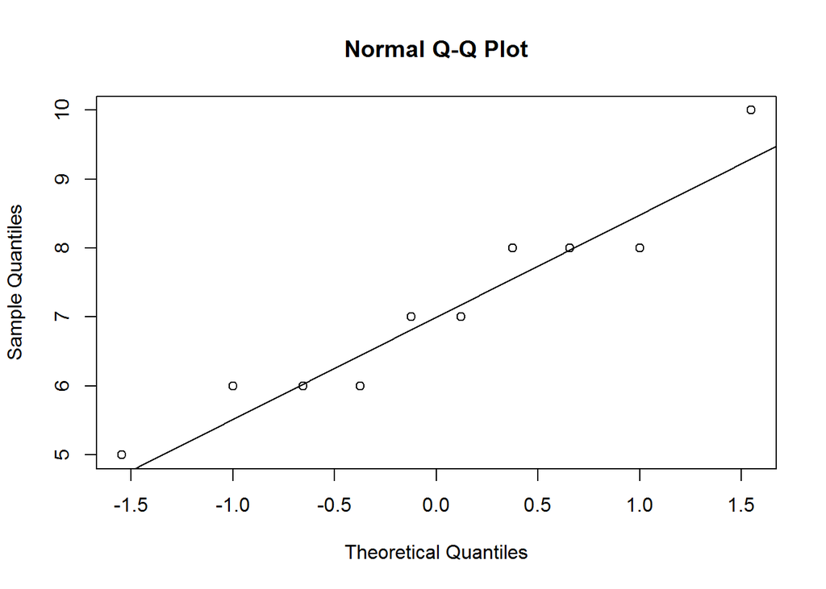

```r
qqnorm(lake1) ; qqline(lake1)
```

```r
shapiro.test(lake2)
```

```
##
##  Shapiro-Wilk normality test
##
## data:  lake2
## W = 0.98106, p-value = 0.9706
```

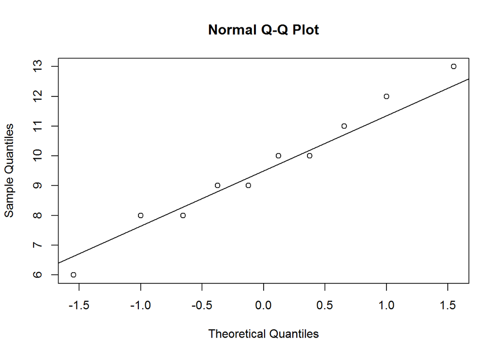

```r
qqnorm(lake2) ; qqline(lake2)
```

```r
shapiro.test(lake3)
```

```
##
##  Shapiro-Wilk normality test
##
## data:  lake3
## W = 0.98022, p-value = 0.9663
```

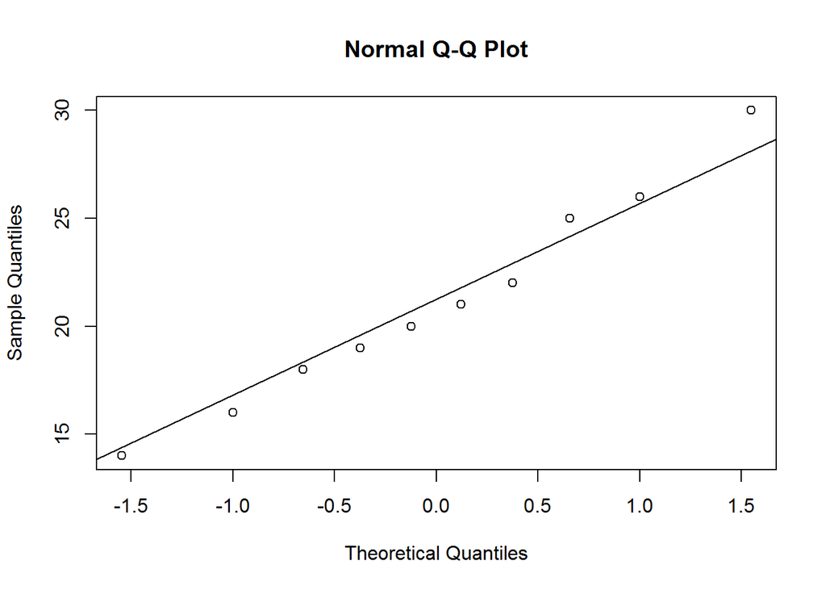

```r
qqnorm(lake3) ; qqline(lake3)
```

검정결과, 모든 호수에 대한 p-value가 유의수준 0.05보다 크게 나왔다. 따라서 각 호수에 대한 산소량은 모두 정규분포를 따른다고 결론내린다.  
이제 각 호수 별 산소량에 대한 분산이 모두 동일한 지 검정한다. 이에 대해서는 Levene의 검정과 Bartlett의 검정이 있다. 모두 세집단 이상의 경우에 대해 등분산성을 검정 시 사용하는 검정법이고 해당 통계량이 특정한 분포에 근사한다는 성질을 이용한다.  
Hypothesis  
H0 : sigma1=sigma2=sigma3 v.s H1 : not H0

```r
library(lawstat)
levene.test(lake$ppm,lake$group)
```

```
##
##  Modified robust Brown-Forsythe Levene-type test based on the
##  absolute deviations from the median
##
## data:  lake$ppm
## Test Statistic = 5.2762, p-value = 0.01164
```

```r
bartlett.test(ppm~group,lake)
```

```
##
##  Bartlett test of homogeneity of variances
##
## data:  ppm by group
## Bartlett's K-squared = 13.214, df = 2, p-value = 0.001351
```

검정결과, 두가지 검정 모두 p-value의 값이 유의수준 0.05보다 작게 나왔다. 따라서 귀무가설을 기각하게 되고, 호수 별 산소량에 대한 분산은 차이가 있다고 결론내린다. 하지만, 각각 호수 별 10개씩 동일한 개수의 표본을 추출하였으므로 이 경우에는 분산분석을 적용하는 데 문제가 없다.  
Hypothesis  
H0 : mu1=mu2=mu3 v.s H1 : not H0

```r
anova(lm(ppm~group,data=lake))
```

```
## Analysis of Variance Table
##
## Response: ppm
##           Df Sum Sq Mean Sq F value    Pr(>F)
## group      2 1115.0  557.50  56.124 2.411e-10 ***
## Residuals 27  268.2    9.93
## ---
## Signif. codes:  0 '***' 0.001 '**' 0.01 '*' 0.05 '.' 0.1 ' ' 1
```

검정결과, p-value의 값이 유의수준 0.05보다 굉장히 작다. 따라서 귀무가설을 기각하게 되고, 이에 따라 각 호수 별 산소량은 차이가 있다고 결론내린다. 그렇다면, 과연 어느 집단에서 차이가 발생하는 지 다중비교를 통해서 확인해보자. 이에 해당하는 방법에는 Tukey의 HSD, Duncan, Scheffe 등 다양한 방법이 존재하고, 모두 특정한 통계량을 계산하여 그 통계량과 각 집단에 대한 표본평균 값의 차이를 비교하여 그룹을 나누게 된다. 다만, Tukey의 HSD 방법이 가장 유연하고, Scheffe의 방법이 가장 엄격하다고 알려져 있다.

#### Tukey HSD

```r
res <- lm(ppm~group,data=lake)
out <- aov(res)
(ph <- TukeyHSD(out))
```

```
##   Tukey multiple comparisons of means
##     95% family-wise confidence level
##
## Fit: aov(formula = res)
##
## $group
##     diff        lwr       upr     p adj
## 2-1  2.5 -0.9947185  5.994718 0.1974223
## 3-1 14.0 10.5052815 17.494718 0.0000000
## 3-2 11.5  8.0052815 14.994718 0.0000000
```

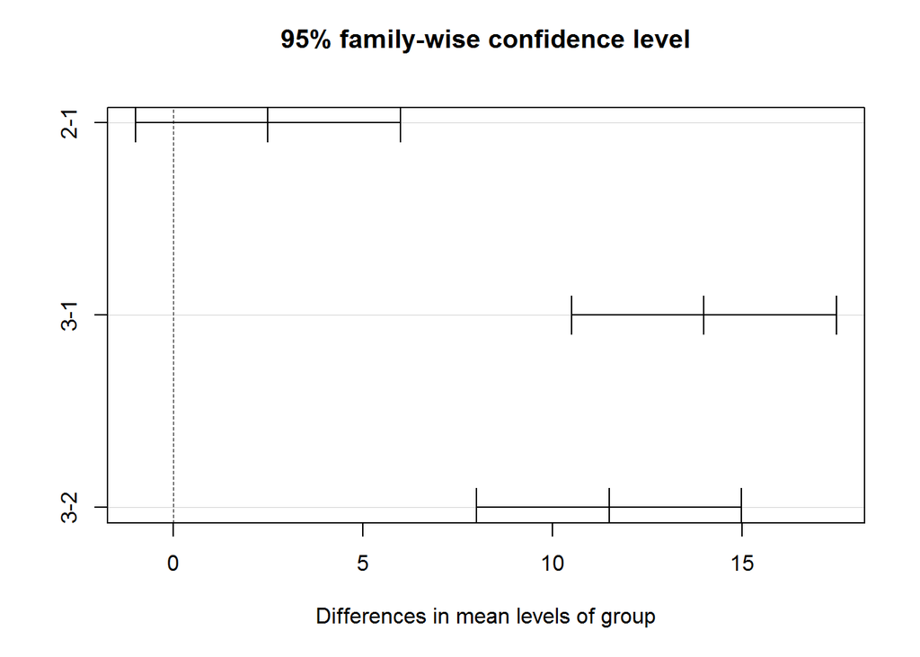

```r
plot(ph)
```

위의 결과에서 맨 오른쪽의 p-value 값을 확인해보면 ‘호수2-호수1’ 을 제외하고는 모두 유의수준 0.05보다 굉장히 작은 값이다. 그러므로 호수3의 산소량이 호수1과 호수2와 비교했을 때 현저히 차이가 난다고 볼 수 있고, 호수1과 호수2의 경우는 차이가 그리 유의하지 않다고 말할 수 있다.

#### Duncan

```r
library(agricolae)  # Duncan, Scheffe test
(res1 <- duncan.test(out,"group",alpha=0.05,group=T,console=T))
```

```
##
## Study: out ~ "group"
##
## Duncan's new multiple range test
## for ppm
##
## Mean Square Error:  9.933333
##
## group,  means
##
##    ppm      std  r Min Max
## 1  7.1 1.449138 10   5  10
## 2  9.6 2.065591 10   6  13
## 3 21.1 4.840799 10  14  30
##
## Alpha: 0.05 ; DF Error: 27
##
## Critical Range
##        2        3
## 2.892038 3.038482
##
## Means with the same letter are not significantly different.
##
##    ppm groups
## 3 21.1      a
## 2  9.6      b
## 1  7.1      b
```

```
## $statistics
##    MSerror Df Mean       CV
##   9.933333 27 12.6 25.01364
##
## $parameters
##     test name.t ntr alpha
##   Duncan  group   3  0.05
##
## $duncan
##      Table CriticalRange
## 2 2.901727      2.892038
## 3 3.048662      3.038482
##
## $means
##    ppm      std  r Min Max   Q25  Q50   Q75
## 1  7.1 1.449138 10   5  10  6.00  7.0  8.00
## 2  9.6 2.065591 10   6  13  8.25  9.5 10.75
## 3 21.1 4.840799 10  14  30 18.25 20.5 24.25
##
## $comparison
## NULL
##
## $groups
##    ppm groups
## 3 21.1      a
## 2  9.6      b
## 1  7.1      b
##
## attr(,"class")
## [1] "group"
```

#### Scheffe

```r
(res2 <- scheffe.test(out,"group",alpha=0.05,group=T,console=T))
```

```
##
## Study: out ~ "group"
##
## Scheffe Test for ppm
##
## Mean Square Error  : 9.933333
##
## group,  means
##
##    ppm      std  r Min Max
## 1  7.1 1.449138 10   5  10
## 2  9.6 2.065591 10   6  13
## 3 21.1 4.840799 10  14  30
##
## Alpha: 0.05 ; DF Error: 27
## Critical Value of F: 3.354131
##
## Minimum Significant Difference: 3.650627
##
## Means with the same letter are not significantly different.
##
##    ppm groups
## 3 21.1      a
## 2  9.6      b
## 1  7.1      b
```

```
## $statistics
##    MSerror Df        F Mean       CV  Scheffe CriticalDifference
##   9.933333 27 3.354131 12.6 25.01364 2.590031           3.650627
##
## $parameters
##      test name.t ntr alpha
##   Scheffe  group   3  0.05
##
## $means
##    ppm      std  r Min Max   Q25  Q50   Q75
## 1  7.1 1.449138 10   5  10  6.00  7.0  8.00
## 2  9.6 2.065591 10   6  13  8.25  9.5 10.75
## 3 21.1 4.840799 10  14  30 18.25 20.5 24.25
##
## $comparison
## NULL
##
## $groups
##    ppm groups
## 3 21.1      a
## 2  9.6      b
## 1  7.1      b
##
## attr(,"class")
## [1] "group"
```

분석결과, Duncan, Schaffe 모두 호수1과 호수2의 산소량은 차이가 미비하고, 나머지 호수3의 산소량이 나머지 두 집단과 차이가 있다는 결론을 주고 있다. 결과적으로 3가지 다중비교 방법 모두 같은 결론을 제시하고 있다.

## 7. 다음은 3개 채소에 대한 도매시장 7곳의 가격이다. 3개 채소의 가격이 같다고 할 수 있는가?

```r
group <- c(rep("A",7),rep("B",7),rep("C",7))
A <- c(15.5,14.3,16.3,13.5,15.7,16.4,14.7)
B <- c(14.7,16.3,15.5,15.2,16.3,13.5,15.4)
C <- c(15.5,13.2,16.5,15.7,15.3,15.2,14.8)
price <- c(A,B,C)
vegetable <- data.frame(group=group,price=price)
```

우선 각 채소별 가격이 정규성을 나타내는 지 검정한다.

```r
shapiro.test(A)
```

```
##
##  Shapiro-Wilk normality test
##
## data:  A
## W = 0.94003, p-value = 0.639
```

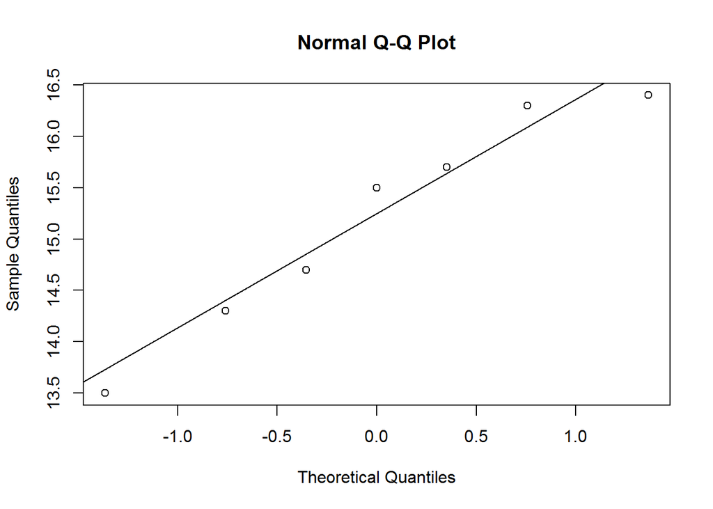

```r
qqnorm(A) ; qqline(A)
```

```r
shapiro.test(B)
```

```
##
##  Shapiro-Wilk normality test
##
## data:  B
## W = 0.91283, p-value = 0.4158
```

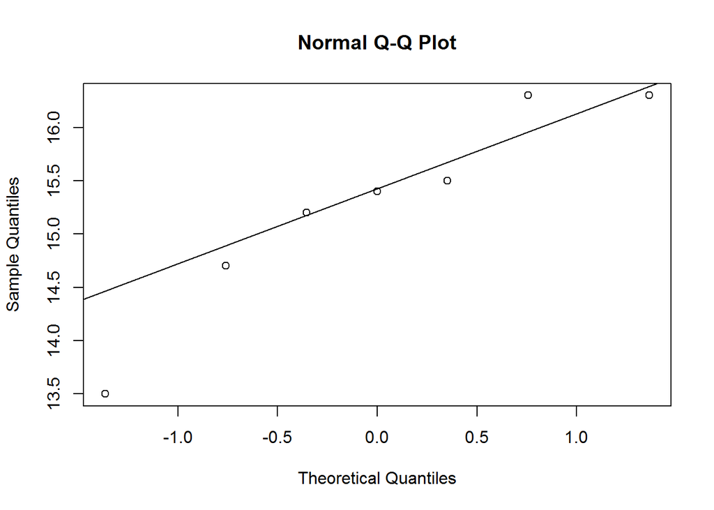

```r
qqnorm(B) ; qqline(B)
```

```r
shapiro.test(C)
```

```
##
##  Shapiro-Wilk normality test
##
## data:  C
## W = 0.90779, p-value = 0.3808
```

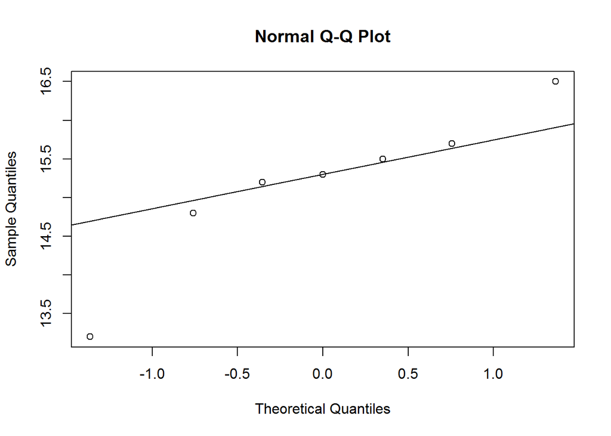

```r
qqnorm(C) ; qqline(C)
```

검정결과, 모든 채소에 대한 p-value가 유의수준 0.05보다 크게 나왔다. 따라서 각 채소별 가격은 모두 정규분포를 따른다고 결론내린다.  
이제 각 채소별 가격에 대한 분산이 모두 동일한 지 검정한다.  
Hypothesis  
H0 : sigma1=sigma2=sigma3 v.s H1 : not H0

```r
levene.test(vegetable$price,vegetable$group)
```

```
##
##  Modified robust Brown-Forsythe Levene-type test based on the
##  absolute deviations from the median
##
## data:  vegetable$price
## Test Statistic = 0.17086, p-value = 0.8443
```

```r
bartlett.test(price~group,vegetable)
```

```
##
##  Bartlett test of homogeneity of variances
##
## data:  price by group
## Bartlett's K-squared = 0.059028, df = 2, p-value = 0.9709
```

```r
anova(lm(price~group,data=vegetable))
```

```
## Analysis of Variance Table
##
## Response: price
##           Df  Sum Sq Mean Sq F value Pr(>F)
## group      2  0.0371 0.01857  0.0178 0.9824
## Residuals 18 18.7886 1.04381
```

검정결과, p-value의 값이 유의수준 0.05보다 굉장히 크다. 따라서 귀무가설을 기각하지 못하게 되고, 이에 따라 각 채소별 가격은 차이가 없다고 결론내린다.

## 8. 어느 공정의 부적합품률은 15% 이다. 시료 80개를 추출하여 검사한 결과 불량이 16개이다. 유의수준 5%로 적합도 검정을 하시오.

1 –> 불량, 2 –> 양호  
Hypothesis  
H0 : p1=0.15, p2=0.85 v.s H1 : not H0

```r
med <- c(16,64)
chisq.test(med,p=c(0.15,0.85))
```

```
##
##  Chi-squared test for given probabilities
##
## data:  med
## X-squared = 1.5686, df = 1, p-value = 0.2104
```

검정결과, p-value의 값이 0.2104로 유의수준 0.05보다 크다. 따라서 귀무가설을 기각하지 못하게 되고, 이에 따라 부적합품률은 15%라고 말할 수 있다.

## 9. 다음은 음주량과 흡연량 데이터이다. 이 표로부터 음주량과 흡연량 사이에 연관이 있는지 확인하시오.

```r
drink <- matrix(c(23,31,13,21,48,23,63,159,119),3,3)
rownames(drink) <- c("반병 이상","반병 이하","못마심")
colnames(drink) <- c("1갑 이상","1갑 이하","안 피움")
addmargins(drink)
```

```
##           1갑 이상 1갑 이하 안 피움 Sum
## 반병 이상       23       21      63 107
## 반병 이하       31       48     159 238
## 못마심          13       23     119 155
## Sum             67       92     341 500
```

Hypothesis  
H0 : 음주량과 흡연량 사이에는 연관이 없다. v.s H1 : not H0

```r
(result <- chisq.test(drink))
```

```
##
##  Pearson's Chi-squared test
##
## data:  drink
## X-squared = 12.827, df = 4, p-value = 0.01215
```

검정결과, p-value의 값이 약 0.012로 유의수준 0.05보다 작다. 따라서 귀무가설을 기각하게 되고, 이에 따라 음주량과 흡연량 사이에는 연관이 있다고 결론내린다.

```r
addmargins(result$expected)
```

```
##           1갑 이상 1갑 이하 안 피움 Sum
## 반병 이상   14.338   19.688  72.974 107
## 반병 이하   31.892   43.792 162.316 238
## 못마심      20.770   28.520 105.710 155
## Sum         67.000   92.000 341.000 500
```